# KD Practicum 4.2

## R modelling fundamentals

Regression models are powerful tools used to effectively solve complex problems in many different domains. The process of building a regression model is normally relatively simple, but can be also complex when is jointly driven by specialists in data science and domain experts.

Although different types of machine learning have different approaches for the model fitting, there are several common steps that are utilized by most modelling scenarios, not just the regression ones. Be sure to include these steps to get the job done:

- Explore your data and choose the function to be fitted (linear, polynomial, quadratic, etc.).
- Create a model
- Mine model object for performance indicators retrieval and downstream analysis
- Generalize your findings for unseen data
- Interpret your findings and refine your model if necessary

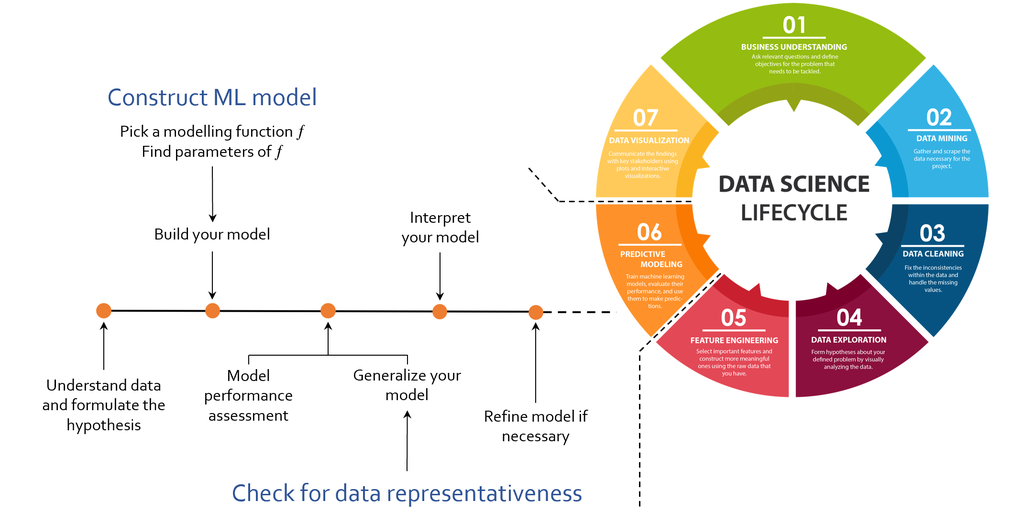

We shall explore most of these steps using simple data. The code that follows requires an installation of the **tidyverse** package, along with packages **magrittr** for pipes and **broom, ggfortify** for polish.

### Data exploration

To demonstrate fundamentals for modeling in base R, let’s use experimental data from McDonald (2009)[^1], by way of Mangiafico (2015)[^2], on the relationship between the ambient temperature and the rate of cricket chirps per minute. Data were collected for two species: *Oecanthus exclamationis* and *Oecanthus niveus*.

The data are contained in a data frame called `modeldata::crickets` with a total of 31 data points and three attributes (species, temp and rate). You load these data by loading tidymodels into R, so `library(tidymodels)` normally suffices.

```
## # A tibble: 3 × 3
##   species           temp  rate
##   <fct>            <dbl> <dbl>
## 1 O. exclamationis  20.8  67.9
## 2 O. exclamationis  20.8  65.1
## 3 O. exclamationis  24    77.3
```

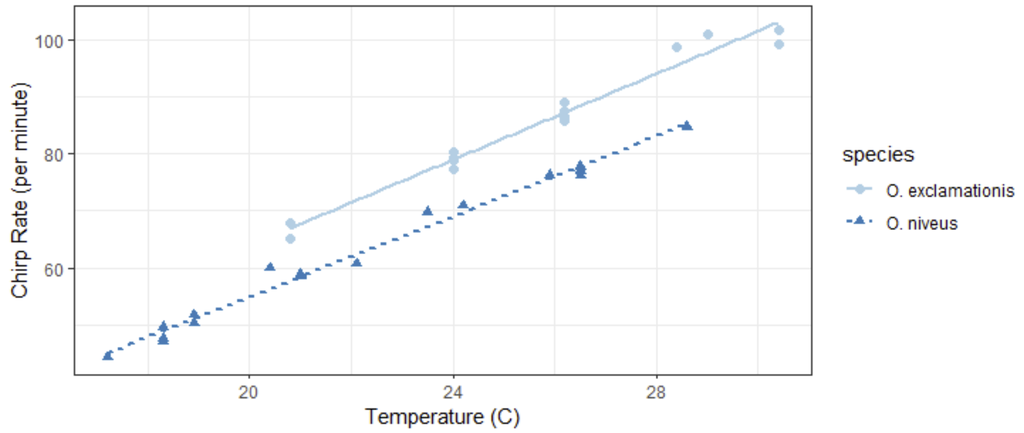

### Hypothesis formulation

The data exhibit fairly linear trends for each species. For a given temperature, O. exclamationis appears to chirp more per minute than the other species. For an inferential model, the researchers might have specified the following null hypotheses prior to seeing the data:

- Temperature has no effect on the chirp rate.
- There are no differences between the species’ chirp rate.

There may be some scientific or practical value in predicting the chirp rate but in this example we will focus on inference.

### Fitting an OLR model

To fit an ordinary linear regression (OLR) model in R, the `lm()` function is commonly used. The important arguments to this function are a *model formula* and a *data frame* that contains the data. The formula is *symbolic*.

For example, the simple formula:

- **`rate ~ temp`** specifies that the chirp rate is the *outcome* (since it is on the left-hand side of the tilde `~`) and that the temperature value is the *predictor*.

The formula can be extended by adding an additional predictor; e.g. for the type of species, which are encoded numerically. Adding species information to the model does not mean that time and encoded class of a species are added together. This formula would symbolically represent that temperature and species should be added as separate *main effects* to the model. We can use **+** in

- **`rate ~ temp + species`** to formulate the model that accounts for the effect of two predictors: temperature and species. This means that for every unit we move on the axis x, there will be two additive effects impacting how much we travel on the y-axis.

> When it comes to the technical details of evaluating expressions, R is lazy (as opposed to eager). This means that model fitting functions typically compute the minimum possible quantities at the last possible moment. For example, if you are interested in the coefficient table for each model term, this is not automatically computed with the model but is instead computed via the `summary()` method.

Returning to our chirping crickets, let’s create an OLR model to see how much temperature and species class influence chirping rate. The `summary()` function ensures that we get the more verbose output.

Note, that here we will use the “**exposition” pipe**: `%$%` . The exposition pipe”exposes” the names within the left-hand side object to the right-hand side expression. This operator is handy when functions do not themselves have a data argument, as for example `lm` does.

```r
model <- crickets %$% lm(rate ~ temp + species)
summary(model)
```

```
##
## Call:
## lm(formula = rate ~ temp + species)
##
## Residuals:
##     Min      1Q  Median      3Q     Max
## -3.0128 -1.1296 -0.3912  0.9650  3.7800
##
## Coefficients:
##                   Estimate Std. Error t value Pr(>|t|)
## (Intercept)       -7.21091    2.55094  -2.827  0.00858 **
## temp               3.60275    0.09729  37.032  < 2e-16 ***
## speciesO. niveus -10.06529    0.73526 -13.689 6.27e-14 ***
## ---
## Signif. codes:  0 '***' 0.001 '**' 0.01 '*' 0.05 '.' 0.1 ' ' 1
##
## Residual standard error: 1.786 on 28 degrees of freedom
## Multiple R-squared:  0.9896, Adjusted R-squared:  0.9888
## F-statistic:  1331 on 2 and 28 DF,  p-value: < 2.2e-16
```

```r
# magrittr package needed for %$% operator
# alternative solution is not to use magrittr but the attach() function
# attach(crickets) ; summary(lm(rate ~ temp + species))
```

It becomes clear that that chirping rate is influenced by temperature; for every degree of Celsius we move on the x-axis, there will be 3.61 unit increase in chirping rate (y-axis).

If your cricket is *Oecanthus Niveus*, the chirping rate will be lower by 10.06 units compared to *Oecanthus exclamationis*. Graphically, we can visualize this relationship between the increasing temperature and chirping rate as follows:

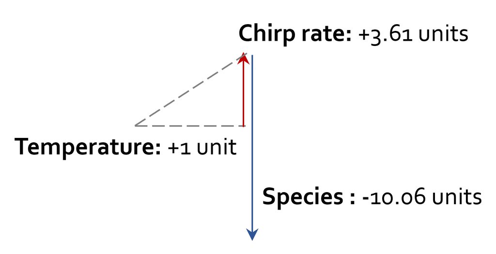

### Mining model objects

Model objects are captured by using the left hand association to a variable name. Thus, typing the following code

- `crickets %$% summary(lm(rate ~ temp + species))` prints model parameters on screen,
- `model <- crickets %$% summary(lm(rate ~ temp + species))` captures the model data into an object. The type of that object is **lm**, which stands for the *linear model*.

```r
class(model) ; typeof(model)
```

```
## [1] "lm"
```

```
## [1] "list"
```

Once captured, model objects are rich source of information that is accessible with built-in functions. You can view the object content, summarize its data, pull out specific information and generate plots. For example:

- **`View(model)`** will display model content in R table viewer.

[figure not shown]

- **`coef(model)`** or **`model$coefficients`** pulls model parameters.
- **`resid(model)`** or **`model$residuals`** pulls model residual values.
- **`fitted(model)`** or **`model$fitted.values`** pulls fitted values predicted by the model.
- **`str(model)`** gives detailed information about each information slot in the list.
- **`predict(model, new.data = …)`** applies trained model parameters to unseen data. Note that new data must be in the same format as the input data, thus including values for all columns.

### The broom package

For OLR calling, we normally use the `stats::lm()` function nested inside the `summary()` function. However, the text output of `summary()` is for most purposes impractical. Hence, we can use the `broom::tidy()` function to convert text information into a tibble, which becomes very handy for downstream analyses.

```r
broom::tidy(model)
```

```
## # A tibble: 3 × 5
##   term             estimate std.error statistic  p.value
##   <chr>               <dbl>     <dbl>     <dbl>    <dbl>
## 1 (Intercept)         -7.21    2.55       -2.83 8.58e- 3
## 2 temp                 3.60    0.0973     37.0  2.49e-25
## 3 speciesO. niveus   -10.1     0.735     -13.7  6.27e-14
```

Broom package also includes the `augment()` function that converts the model object into fully fledged information that can be used, for example in graphics with the ggplot library.

```r
broom::augment(model) %>% head()
```

```
## # A tibble: 6 × 9
##    rate  temp species          .fitted .resid   .hat .sigma  .cooksd .std.resid
##   <dbl> <dbl> <fct>              <dbl>  <dbl>  <dbl>  <dbl>    <dbl>      <dbl>
## 1  67.9  20.8 O. exclamationis    67.7  0.174 0.144    1.82 0.000621     0.105
## 2  65.1  20.8 O. exclamationis    67.7 -2.63  0.144    1.74 0.142       -1.59
## 3  77.3  24   O. exclamationis    79.3 -1.96  0.0806   1.78 0.0381      -1.14
## 4  78.7  24   O. exclamationis    79.3 -0.555 0.0806   1.82 0.00307     -0.324
## 5  79.4  24   O. exclamationis    79.3  0.145 0.0806   1.82 0.000209     0.0846
## 6  80.4  24   O. exclamationis    79.3  1.14  0.0806   1.80 0.0131       0.668
```

### Model quality indicators

Before going into any inferential results for this model, the fit should be assessed using diagnostic plots. We can use the `plot()` method for any regular `lm` object. The exist also an advanced version of `plot()` — `autoplot()` — implemented in the **ggfortify** package. Both methods produce almost identical set of plots from the data contained within the lm object, each showing different aspects of model fit.

- **Residuals vs. Fitted values:** This plot allows us to check for homoscedasticity. That is kind of check whether the variance of the residual in a regression model is constant. It is in our example, so we continue.
- **Quantile-Quantile plot:** Q-Q plots are used to determine whether data are *normally* distributed, which is one condition for an OLR modelling to work. Here, our data conform to the normal distribution reasonably well, albeit not perfectly.
- **High-leverage points:** are outliers that have an impact on the fitting parameters. Quick glance at the plot tells us that no such data points are in our data set.

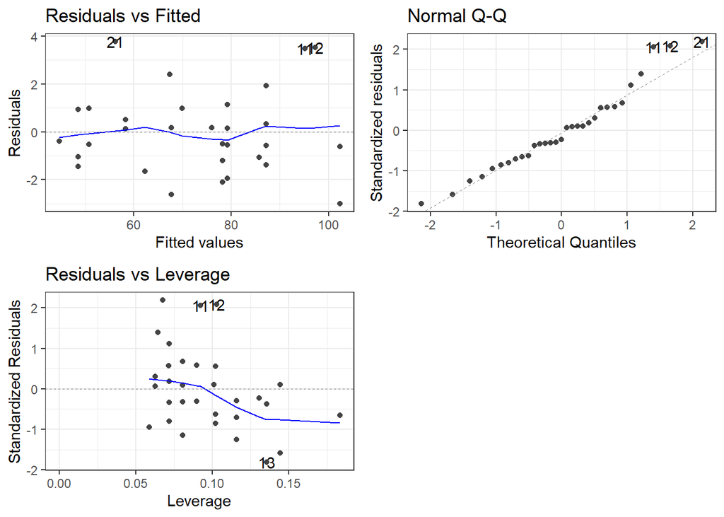

```r
library(ggfortify)
autoplot(model, which = c(1,2,5)) + theme_bw()
```

Residual diagnostic plots for the linear model without interaction appear reasonable enough to conduct inferential analysis. These plots should be assessed to make sure that our theoretical assumptions are valid enough to trust the p-values produced by the model. We can use the `summary()` method again to inspect the coefficients, standard errors, and p-values of each model term:

```r
summary(model)
```

```
##
## Call:
## lm(formula = rate ~ temp + species)
##
## Residuals:
##     Min      1Q  Median      3Q     Max
## -3.0128 -1.1296 -0.3912  0.9650  3.7800
##
## Coefficients:
##                   Estimate Std. Error t value Pr(>|t|)
## (Intercept)       -7.21091    2.55094  -2.827  0.00858 **
## temp               3.60275    0.09729  37.032  < 2e-16 ***
## speciesO. niveus -10.06529    0.73526 -13.689 6.27e-14 ***
## ---
## Signif. codes:  0 '***' 0.001 '**' 0.01 '*' 0.05 '.' 0.1 ' ' 1
##
## Residual standard error: 1.786 on 28 degrees of freedom
## Multiple R-squared:  0.9896, Adjusted R-squared:  0.9888
## F-statistic:  1331 on 2 and 28 DF,  p-value: < 2.2e-16
```

The chirp rate for each species increases by 3.6 chirps as the temperature increases by a single degree. This term shows strong statistical significance as evidenced by the p-value. The species term has a value of -10.07. This indicates that, across all temperature values, *O. niveus* has a chirp rate that is about 10 fewer chirps per minute than *O. exclamationis*. Similar to the temperature term, the species effect is associated with a very small p-value.

The only issue in this analysis is the intercept value. It indicates that at 0° C, there are negative chirps per minute for both species. While this doesn’t make sense, the data only go as low as 17.2° C and interpreting the model at 0° C would be an extrapolation. This would be a bad idea. That being said, the model fit is good within the *applicable range* of the temperature values; the conclusions should be limited to the observed temperature range.

### Predicting from unseen data

If we needed to estimate the chirp rate at a temperature that was not observed in the experiment, we could use the `predict()` method. It takes the model object and a data frame of new values for prediction. For example, the model estimates the chirp rate for *O. exclamationis* for temperatures between 15° C and 20° C can be computed via:

```r
new_values <- tibble(species = "O. exclamationis", temp = 15:20)
head(new_values, n=3)
```

```
## # A tibble: 3 × 2
##   species           temp
##   <chr>            <int>
## 1 O. exclamationis    15
## 2 O. exclamationis    16
## 3 O. exclamationis    17
```

```r
predict(model, new_values)
```

```
##        1        2        3        4        5        6
## 46.83039 50.43314 54.03589 57.63865 61.24140 64.84415
```

## Exercises

### Background

According to the statistics, 80% of professional football players are right footed, which means that left footed players are something of a rarity. However, when we consider some of the greatest names to play the game, we do start to see a trend that some of the best players — **Lionel Messi**, **Ferenc Puskas** and **Diego Maradona** — have ever have been lefty’s.

Both Messi and Maradona played as attacking midfielders. Especially Maradona enjoyed a free role as either an attacking midfielder who would sit behind the strikers, or as a second striker in a front-two.

His *dribbling* was his best attribute and is often used as a barometer when it comes to discussing how well one of today’s players can run with the ball at their feet.

Just like Lionel Messi, the ball seemed to stick to Maradona’s feet and this terrified opposition defences. His immense dribbling ability also saw him score some of football’s most iconic goals, one example being his second against England at the 1986 World Cup which is considered by many to be the greatest individual goal in the tournament’s history.

### Hypothesis-driven modelling

Lionel Messi and Diego Maradona were some of the best paid players in soccer history. One can truly wonder whether their wages would be higher have they had been right-footed players. To investigate if there’s a grain of truth that right-footed midfielders are paid better, you will use the `player_22.csv` data.

Your task is to explore how much the wage of **attacking midfielder** depends on ball control, represented by **skill_dribbling** and **skill__curve** attributes, in relation to the player’s **preferred_foot**.

As said, skill_dribbling is often used as a barometer when it comes to discussing how well one of today’s players can run with the ball at their feet. Skill_curve expresses the payer’s ability of curving the soccer ball — also known as *bending.* Bending is important because it really deceives the goalkeeper, deceives the defenders, and just puts that little extra spin on the ball that creates a good goal-scoring opportunity.

A quick glance at the data tells us there is indeed a relation between the player’s control of a ball and hence we can go forward by assuming that the better the player masters that skill, the higher wage he can possibly negotiate.

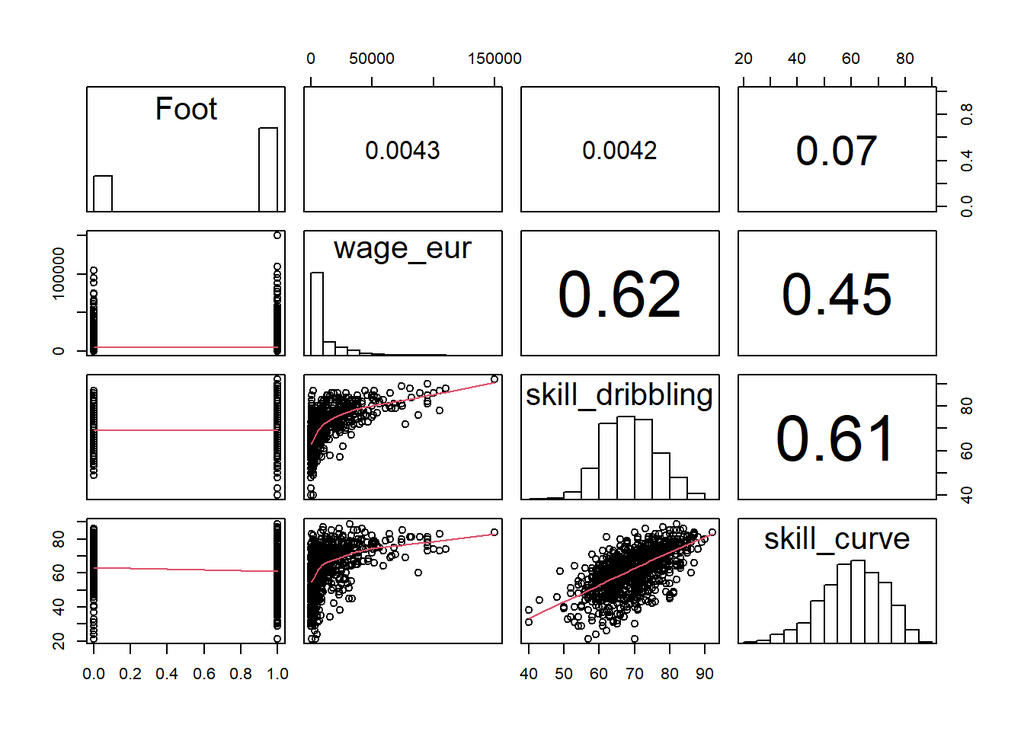

The pair plot show below depicts mutual relationships between the studied attributes. The upper triangle depicts correlation coefficients, the central axis depicts name of a given variable and a histogram, and the lower triangle depicts scatter plots with smoothing spline fitted onto the data.

### Building an OLR model

Your principal task is to use `Practicum.4.2.csv` data to regress the wage of a midfielder attacker onto his dribbling and ball curving skills and preferred playing foot. That would mean that you have to:

1. Load `Practicum.4.2.csv` into R.

```
## # A tibble: 5 × 6
##   sofifa_id wage_eur preferred_foot player_positions Skill              Value
##       <dbl>    <dbl> <chr>          <chr>            <chr>              <dbl>
## 1    182521   310000 Right          CM               skill_moves            3
## 2    182521   310000 Right          CM               skill_dribbling       80
## 3    182521   310000 Right          CM               skill_curve           86
## 4    182521   310000 Right          CM               skill_fk_accuracy     84
## 5    182521   310000 Right          CM               skill_long_passing    93
```

The data are in tidy format, so your first task is to transform them for use in ordinary linear regression.

```r
data %<>%
  pivot_wider(names_from = "Skill", values_from = "Value")
head(data, n=5)
```

```
## # A tibble: 5 × 10
##   sofifa_id wage_eur preferred…¹ playe…² skill…³ skill…⁴ skill…⁵ skill…⁶ skill…⁷
##       <dbl>    <dbl> <chr>       <chr>     <dbl>   <dbl>   <dbl>   <dbl>   <dbl>
## 1    182521   310000 Right       CM            3      80      86      84      93
## 2    177003   190000 Right       CM            4      85      85      78      89
## 3    189513    64000 Right       CM            3      82      88      90      90
## 4    224232   120000 Right       CM            3      83      75      67      79
## 5    225193    47000 Left        CM            3      83      80      69      82
## # … with 1 more variable: skill_ball_control <dbl>, and abbreviated variable
## #   names ¹preferred_foot, ²player_positions, ³skill_moves, ⁴skill_dribbling,
## #   ⁵skill_curve, ⁶skill_fk_accuracy, ⁷skill_long_passing
```

2. Build an **OLR model with multiple predictors** to predict attacking midfielder’s wage from dribbling, ball curving skills and player’s preferred foot for play.
3. Use you model object to extract more information about the model’s quality. Double check for signs of homoscedascticity and uneven distribution of data across quantiles, and think how to mend possible errors.

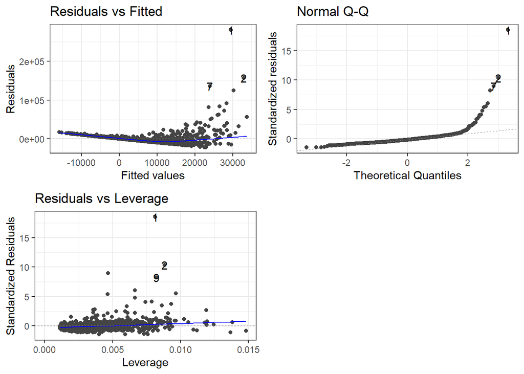

```r
library(ggfortify)
model <- data%$% lm(wage_eur ~ skill_dribbling + skill_curve + preferred_foot)
autoplot(model, which = c(1,2,5)) + theme_bw()
```

4. Display OLR model summary. Are there predictors that are not statistically significant? At which statistical level? Would they become statistically significant if they are subjected for OLR modelling individually?

```r
library(broom)
tidy(model)
```

```
## # A tibble: 4 × 5
##   term                estimate std.error statistic  p.value
##   <chr>                  <dbl>     <dbl>     <dbl>    <dbl>
## 1 (Intercept)          -58625.    3759.     -15.6  8.82e-50
## 2 skill_dribbling         726.      79.3      9.15 2.52e-19
## 3 skill_curve             305.      55.2      5.52 4.20e- 8
## 4 preferred_footRight    3908.    1126.       3.47 5.41e- 4
```

5. A quick glance on pair plots tells you that dribbling and curving skills are related. To accommodate this effect into the model, we need to build an **OLR model with interactions**. R can do just that with a slight change of syntax. Find the correct syntax by researching online material, web pages, or the available `lm()` documentation.
6. Generate summary for the new OLR model with interaction between skill_dribble and skill_curve. How much do model parameters differ from those of OLR model without interaction? How would you interpret that interaction?

```r
model <- data%$% lm(wage_eur ~ skill_dribbling : skill_curve + preferred_foot)
tidy(model)
```

```
## # A tibble: 3 × 5
##   term                         estimate std.error statistic  p.value
##   <chr>                           <dbl>     <dbl>     <dbl>    <dbl>
## 1 (Intercept)                 -25476.    1769.       -14.4  2.67e-43
## 2 preferred_footRight           4110.    1103.         3.73 2.03e- 4
## 3 skill_dribbling:skill_curve      8.33     0.394     21.1  9.45e-84
```

7. R also provides a shortcut `()^2` to expand interactions for all attributes within the parenthesis; i.e. skill_dribble, skill_curve and preferred_foot. Let’s investigate how the model parameters will change if we attempt to apply that.

```r
model <- data%$% lm(wage_eur ~ (skill_dribbling + skill_curve + preferred_foot)^2)
tidy(model)
```

```
## # A tibble: 7 × 5
##   term                                estimate std.error statistic  p.value
##   <chr>                                  <dbl>     <dbl>     <dbl>    <dbl>
## 1 (Intercept)                         220759.   14927.       14.8  2.41e-45
## 2 skill_dribbling                      -3487.     255.      -13.7  2.02e-39
## 3 skill_curve                          -4614.     254.      -18.2  6.64e-65
## 4 preferred_footRight                 -37433.    8265.       -4.53 6.56e- 6
## 5 skill_dribbling:skill_curve             72.9      3.56     20.5  1.84e-79
## 6 skill_dribbling:preferred_footRight    476.     175.        2.71 6.78e- 3
## 7 skill_curve:preferred_footRight        178.     114.        1.57 1.17e- 1
```

8. Using ordinary regression to fit a straight line onto the data might not provide the best model. Let’s create a cubic fit and a polynomial fit of 5th-degree by means of the `poly()` function that is inserted into the model parameters of `lm()`.

Note that interactions cannot be inserted into the polynomial, so we can apply the `poly()` function to either of the skills. Let’s inspect the following model:

```r
model <- data%$% lm(wage_eur ~ poly(skill_dribbling, 5) + skill_curve + preferred_foot)
tidy(model)
```

```
## # A tibble: 8 × 5
##   term                      estimate std.error statistic  p.value
##   <chr>                        <dbl>     <dbl>     <dbl>    <dbl>
## 1 (Intercept)                -10740.    2735.      -3.93 9.16e- 5
## 2 poly(skill_dribbling, 5)1  206367.   18727.      11.0  6.96e-27
## 3 poly(skill_dribbling, 5)2  235364.   12979.      18.1  1.22e-64
## 4 poly(skill_dribbling, 5)3  127557.   12984.       9.82 6.62e-22
## 5 poly(skill_dribbling, 5)4   16717.   12937.       1.29 1.97e- 1
## 6 poly(skill_dribbling, 5)5  -28691.   12931.      -2.22 2.67e- 2
## 7 skill_curve                   280.      47.3      5.92 4.18e- 9
## 8 preferred_footRight          2893.     960.       3.01 2.63e- 3
```

From these data, we can see that the the variance explained by higher order polynomials becomes smaller and smaller once they pass certain complexity. Cubic, that is in our case.

9. At this stage, you should have built several models: pick one you like, retrieve the residuals from the model object and calculate:
   - Residual sum of squares
   - Mean squared error
10. **(Optional)** Explore simple relation between **wage_eur** and **skill_curve**. Plot linear, cubic and polynomial fits onto data using geoms from the ggplot2 library.
11. **(Optional)** Do some research how to calculate these fits externally and add the `lm()`-fitted data to the plot as a separate layer. This is often the right way how to separate the modelling process from the visualization, thereby allowing for more precise tune-up of the fitting.
12. Let’s summarize your findings. Although there is no definite way to estimate the value of your models, think how would yo answer the following:
    - What makes a model believable? Is it the P value that is calculated for each model parameter, or the residual standard error?
    - Is is better to create several simpler models, or one that allows for multiple predictors to be modeled simultaneously? Which of modeled predictors will lose statistical significance when modeled individually? Why?
    - Which error metric should be used for model explanation and which for general model comparison?
    - Which degree of model flexibility would give you best bias-variance trade-off? Which degree of model flexibility is best used when interpretation is the goal?
    - Which predictors would you suggest to model with and which without the interaction?

### References

[^1]: McDonald, J. 2009. *Handbook of Biological Statistics*. Sparky House Publishing.
[^2]: Mangiafico, S. 2015. “An R Companion for the Handbook of Biological Statistics.” https://rcompanion.org/handbook/.